# Лабораторная работа № 12

Программирование в командном процессоре ОС UNIX. Командные файлы

Чжан Вэньцзюнь

Российский университет дружбы народов

РУДН

2026-10-20

# Информация

## Докладчик

- Чжан Вэньцзюнь
- зачётная книжка № 1132259051
- Российский университет дружбы народов им. П. Лумумбы

## Цель работы

- Изучить основы программирования в оболочке ОС UNIX/Linux
- Научиться писать небольшие командные файлы
- Освоить переменные, параметры и управляющие конструкции bash

## Задание

1. Скрипт резервной копии самого себя в `~/backup` (`tar`/`zip`/`bzip2`)
2. Скрипт обработки произвольного числа аргументов (в том числе > 10)
3. Аналог команды `ls` без использования `ls` и `dir`
4. Скрипт подсчёта файлов заданного формата в указанной директории

# Теоретические сведения

## Командные оболочки

- `sh` — оболочка Борна, базовый набор
- `csh` — C-подобный синтаксис, история команд
- `ksh` — оболочка Корна
- `bash` — Bourne Again Shell, свойства `csh` и `ksh`

## Переменные и специальные параметры

| Переменная | Назначение |
| --- | --- |
| `$0` | имя запущенного файла |
| `$1`…`${10}` | позиционные параметры |
| `$#` | число параметров |
| `$*`, `$@` | все параметры |
| `$?` | код возврата |
| `$$` | PID оболочки |
| `$!` | PID фонового процесса |

## Управляющие конструкции

```bash
if [ -d "$DIR" ]; then ...; fi
for f in "$@"; do ...; done
while [ ... ]; do ...; done
case "$x" in *.txt) ...;; esac
```

# Выполнение работы

## 1. Резервная копия самого себя

```bash
#!/bin/bash
DEST="$HOME/backup"
mkdir -p "$DEST"
STAMP=$(date +%Y%m%d-%H%M%S)
tar -czf "$DEST/$(basename "$0").$STAMP.tar.gz" "$0"
```

- `$0` — путь к самому скрипту
- `tar -czf` — создание архива с gzip-сжатием
- архив проверен: `tar -tzf ~/backup/*.tar.gz`

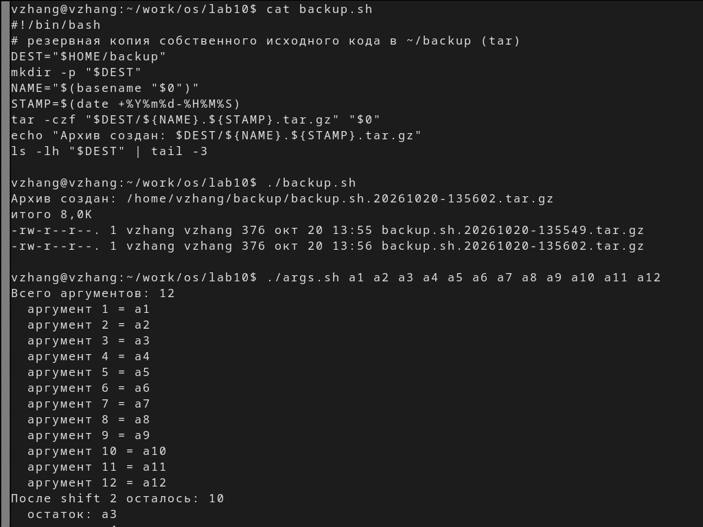

Работа скриптов backup.sh и args.sh

## 2. Обработка произвольного числа аргументов

```bash
for a in "$@"; do echo "аргумент: $a"; done
shift 2
echo "осталось: $#"
```

- `"$@"` корректно перебирает любое число аргументов
- `$#` — количество, `shift n` — сдвиг списка

## 3. Аналог команды ls

```bash
for f in "$DIR"/* "$DIR"/.[!.]*; do
  [ -e "$f" ] || continue
  printf '%-48s %s\n' "$(basename "$f")" "$(stat -c '%A %U:%G %6s %y' "$f")"
done
```

- Не используются `ls` и `dir`
- Права доступа — через `stat %A`
- Выводятся и скрытые файлы (`.[!.]*`)

## 4. Подсчёт файлов заданного формата

```bash
EXT="${1:?укажите формат}"
DIR="${2:-.}"
n=0
for f in "$DIR"/*."$EXT"; do [ -f "$f" ] && n=$((n+1)); done
echo "Файлов .$EXT в $DIR: $n"
```

- `${1:?}` — обязательный аргумент с сообщением
- `${2:-.}` — значение по умолчанию
- результат: `.sh` — 4 файла, `.png` — 3 файла

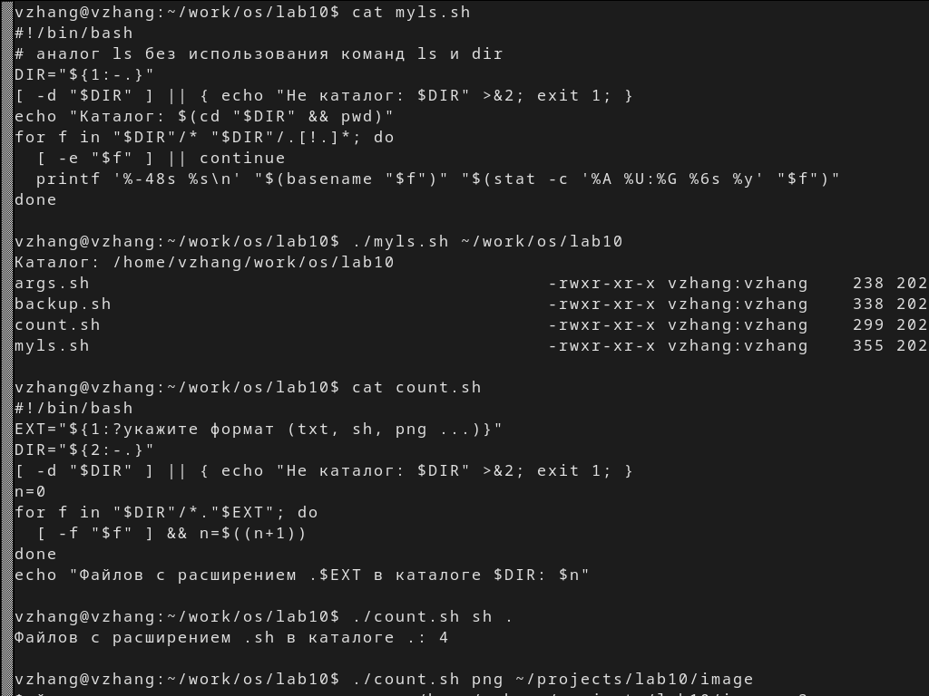

Работа скриптов myls.sh и count.sh

# Заключение

## Выводы

- Изучены переменные, подстановка и арифметика в `bash`
- Освоена передача параметров (`$0`, `$1`, `$#`, `$@`, `shift`)
- Изучены управляющие конструкции (`if`, `for`, `while`, `case`)
- Написаны и проверены 4 командных файла
- Освоены `tar`, `stat`, шаблоны имён и экранирование

## Спасибо за внимание!

Вопросы?